# AIML_ML_Project_Full_Code_Notebook_(Desicion_Tree_vs_Logistic_Regression_+_Zip_Code_Included)

## Problem Statement

### Context

AllLife Bank is a mid-sized, fast-growing US-based financial institution that offers a range of retail banking services, including savings and checking accounts, fixed deposits, and personal loans. The bank’s business model is centered on building long-term customer relationships, expanding its retail footprint, and growing its loan portfolio to drive sustainable profitability through interest income.

It currently relies on a large base of liability customers (depositors) but faces a significant under-representation of asset customers (borrowers). To drive profitability through interest income, the bank must aggressively expand its loan portfolio by converting existing depositors into personal loan customers.

Last year’s pilot campaign achieved a 9% conversion rate, validating the potential of this strategy. However, to optimize marketing spend and improve efficiency, the retail marketing department requires a more data-driven approach. Enhancing the success ratio of these campaigns is critical for sustainable growth and maximizing customer lifetime value.

### Objective

The objective is to develop a predictive classification model that identifies patterns and key factors driving personal loan adoption among existing liability customers. By uncovering the demographic and behavioral drivers of loan conversion, the goal is to enable targeted segmentation and more precise marketing interventions that improve campaign conversion rates, optimize marketing spend, and enhance overall profitability through higher-quality loan portfolio growth.

### Data Dictionary

- `ID`: Customer ID
- `Age`: Customer’s age in completed years
- `Experience`: #years of professional experience
- `Income`: Annual income of the customer (in thousand dollars)
- `ZIP Code`: Home Address ZIP code.
- `Family`: the Family size of the customer
- `CCAvg`: Average spending on credit cards per month (in thousand dollars)
- `Education`: Education Level. 1: Undergrad; 2: Graduate;3: Advanced/Professional
- `Mortgage`: Value of house mortgage if any. (in thousand dollars)
- `Personal_Loan`: Did this customer accept the personal loan offered in the last campaign? (0: No, 1: Yes)
- `Securities_Account`: Does the customer have securities account with the bank? (0: No, 1: Yes)
- `CD_Account`: Does the customer have a certificate of deposit (CD) account with the bank? (0: No, 1: Yes)
- `Online`: Do customers use internet banking facilities? (0: No, 1: Yes)
- `CreditCard`: Does the customer use a credit card issued by any other Bank (excluding All life Bank)? (0: No, 1: Yes)

## Importing necessary libraries

```python
# Installing the libraries with the specified version.
!pip install numpy==2.0.2 pandas==2.2.2 matplotlib==3.10.0 seaborn==0.13.2 scikit-learn==1.6.1 sklearn-pandas==2.2.0 -q --user
```

**Note**:

1. After running the above cell, kindly restart the notebook kernel (for Jupyter Notebook) or runtime (for Google Colab), write the relevant code for the project from the next cell, and run all cells sequentially from the next cell.
2. On executing the above line of code, you might see a warning regarding package dependencies. This error message can be ignored as the above code ensures that all necessary libraries and their dependencies are maintained to successfully execute the code in this notebook.

```python
# to load and manipulate data
import pandas as pd
import numpy as np

# to visualize data
import matplotlib.pyplot as plt
import seaborn as sns

# to split data
from sklearn.model_selection import train_test_split, GridSearchCV

# to build decision tree
from sklearn.tree import DecisionTreeClassifier
from sklearn import tree

# to build logistic regression
from sklearn.linear_model import LogisticRegression
from sklearn.pipeline import Pipeline
from sklearn.preprocessing import StandardScaler

# to evaluate model
from sklearn.metrics import (
    confusion_matrix,
    accuracy_score,
    recall_score,
    precision_score,
    f1_score,
    precision_recall_curve,
)

import warnings
warnings.filterwarnings('ignore')
```

## Loading the dataset

```python
# uncomment and run the below code snippets if the dataset is present in the Google Drive
from google.colab import drive
drive.mount('/content/drive')
```

```python
# loading data into a pandas dataframe
loan_data = pd.read_csv('/content/drive/MyDrive/Colab Notebooks/AllLifeBank/Loan_Modelling.csv')
```

```python
# creating a copy of the data
data = loan_data.copy()
```

## Data Overview

- Observations
- Sanity checks

```python
# First and last 5 rows
print('First 5 rows:')
display(data.head())
print('\nLast 5 rows:')
display(data.tail())
```

```
First 5 rows:
```

|  | ID | Age | Experience | Income | ZIPCode | Family | CCAvg | Education | Mortgage | Personal_Loan | Securities_Account | CD_Account | Online | CreditCard |
| --- | --- | --- | --- | --- | --- | --- | --- | --- | --- | --- | --- | --- | --- | --- |
| 0 | 1 | 25 | 1 | 49 | 91107 | 4 | 1.6 | 1 | 0 | 0 | 1 | 0 | 0 | 0 |
| 1 | 2 | 45 | 19 | 34 | 90089 | 3 | 1.5 | 1 | 0 | 0 | 1 | 0 | 0 | 0 |
| 2 | 3 | 39 | 15 | 11 | 94720 | 1 | 1.0 | 1 | 0 | 0 | 0 | 0 | 0 | 0 |
| 3 | 4 | 35 | 9 | 100 | 94112 | 1 | 2.7 | 2 | 0 | 0 | 0 | 0 | 0 | 0 |
| 4 | 5 | 35 | 8 | 45 | 91330 | 4 | 1.0 | 2 | 0 | 0 | 0 | 0 | 0 | 1 |

```
Last 5 rows:
```

|  | ID | Age | Experience | Income | ZIPCode | Family | CCAvg | Education | Mortgage | Personal_Loan | Securities_Account | CD_Account | Online | CreditCard |
| --- | --- | --- | --- | --- | --- | --- | --- | --- | --- | --- | --- | --- | --- | --- |
| 4995 | 4996 | 29 | 3 | 40 | 92697 | 1 | 1.9 | 3 | 0 | 0 | 0 | 0 | 1 | 0 |
| 4996 | 4997 | 30 | 4 | 15 | 92037 | 4 | 0.4 | 1 | 85 | 0 | 0 | 0 | 1 | 0 |
| 4997 | 4998 | 63 | 39 | 24 | 93023 | 2 | 0.3 | 3 | 0 | 0 | 0 | 0 | 0 | 0 |
| 4998 | 4999 | 65 | 40 | 49 | 90034 | 3 | 0.5 | 2 | 0 | 0 | 0 | 0 | 1 | 0 |
| 4999 | 5000 | 28 | 4 | 83 | 92612 | 3 | 0.8 | 1 | 0 | 0 | 0 | 0 | 1 | 1 |

```python
# Shape of the dataset
print(f'Dataset shape: {data.shape}')
print(f'Total customers: {data.shape[0]} | Total features: {data.shape[1]}')
```

```
Dataset shape: (5000, 14)
Total customers: 5000 | Total features: 14
```

```python
data.info()
```

```
<class 'pandas.core.frame.DataFrame'>
RangeIndex: 5000 entries, 0 to 4999
Data columns (total 14 columns):
 #   Column              Non-Null Count  Dtype
---  ------              --------------  -----
 0   ID                  5000 non-null   int64
 1   Age                 5000 non-null   int64
 2   Experience          5000 non-null   int64
 3   Income              5000 non-null   int64
 4   ZIPCode             5000 non-null   int64
 5   Family              5000 non-null   int64
 6   CCAvg               5000 non-null   float64
 7   Education           5000 non-null   int64
 8   Mortgage            5000 non-null   int64
 9   Personal_Loan       5000 non-null   int64
 10  Securities_Account  5000 non-null   int64
 11  CD_Account          5000 non-null   int64
 12  Online              5000 non-null   int64
 13  CreditCard          5000 non-null   int64
dtypes: float64(1), int64(13)
memory usage: 547.0 KB
```

```python
# Statistical summary
data.describe(include='all').T
```

|  | count | mean | std | min | 25% | 50% | 75% | max |
| --- | --- | --- | --- | --- | --- | --- | --- | --- |
| ID | 5000.0 | 2500.500000 | 1443.520003 | 1.0 | 1250.75 | 2500.5 | 3750.25 | 5000.0 |
| Age | 5000.0 | 45.338400 | 11.463166 | 23.0 | 35.00 | 45.0 | 55.00 | 67.0 |
| Experience | 5000.0 | 20.104600 | 11.467954 | -3.0 | 10.00 | 20.0 | 30.00 | 43.0 |
| Income | 5000.0 | 73.774200 | 46.033729 | 8.0 | 39.00 | 64.0 | 98.00 | 224.0 |
| ZIPCode | 5000.0 | 93169.257000 | 1759.455086 | 90005.0 | 91911.00 | 93437.0 | 94608.00 | 96651.0 |
| Family | 5000.0 | 2.396400 | 1.147663 | 1.0 | 1.00 | 2.0 | 3.00 | 4.0 |
| CCAvg | 5000.0 | 1.937938 | 1.747659 | 0.0 | 0.70 | 1.5 | 2.50 | 10.0 |
| Education | 5000.0 | 1.881000 | 0.839869 | 1.0 | 1.00 | 2.0 | 3.00 | 3.0 |
| Mortgage | 5000.0 | 56.498800 | 101.713802 | 0.0 | 0.00 | 0.0 | 101.00 | 635.0 |
| Personal_Loan | 5000.0 | 0.096000 | 0.294621 | 0.0 | 0.00 | 0.0 | 0.00 | 1.0 |
| Securities_Account | 5000.0 | 0.104400 | 0.305809 | 0.0 | 0.00 | 0.0 | 0.00 | 1.0 |
| CD_Account | 5000.0 | 0.060400 | 0.238250 | 0.0 | 0.00 | 0.0 | 0.00 | 1.0 |
| Online | 5000.0 | 0.596800 | 0.490589 | 0.0 | 0.00 | 1.0 | 1.00 | 1.0 |
| CreditCard | 5000.0 | 0.294000 | 0.455637 | 0.0 | 0.00 | 0.0 | 1.00 | 1.0 |

**Observations:**

- The dataset has **5,000 customers** and **14 features**.
- `ID` is a unique customer identifier — not predictive and will be dropped.
- `ZIPCode` is a postal code that, as a high-cardinality categorical feature, will require further analysis and potential treatment.
- `Experience` shows a minimum of **-3 years** — negative experience is anomalous and needs treatment.
- `Mortgage` has a minimum of 0 (customers with no mortgage) which is valid.
- `Income`, `CCAvg`, and `Mortgage` have wide ranges, suggesting outliers worth investigating.
- `Personal_Loan` is the binary target: 0 = declined, 1 = accepted.

```python
# Missing values
print('Missing values per column:')
print(data.isnull().sum())
```

```
Missing values per column:
ID                    0
Age                   0
Experience            0
Income                0
ZIPCode               0
Family                0
CCAvg                 0
Education             0
Mortgage              0
Personal_Loan         0
Securities_Account    0
CD_Account            0
Online                0
CreditCard            0
dtype: int64
```

- There are **no missing values** in the dataset.

```python
print(f'Duplicate rows: {data.duplicated().sum()}')
```

```
Duplicate rows: 0
```

- There are **no duplicate rows** in the dataset.

```python
# Target variable distribution
print('Personal_Loan value counts:')
print(data['Personal_Loan'].value_counts())
print('\nPercentage distribution:')
print(data['Personal_Loan'].value_counts(normalize=True).mul(100).round(2))
```

```
Personal_Loan value counts:
Personal_Loan
0    4520
1     480
Name: count, dtype: int64

Percentage distribution:
Personal_Loan
0    90.4
1     9.6
Name: proportion, dtype: float64
```

- **90.4% of customers (4,520) did NOT accept** the personal loan offer.
- **9.6% of customers (480) DID accept** the personal loan offer.
- The dataset is **highly imbalanced** — this must be accounted for during model building.

## Exploratory Data Analysis.

EDA is a critical step in any data project used to investigate and understand the data before model construction.

The following questions serve as a starting point to help you approach the analysis and generate initial insights:

**Questions**:

1. What is the distribution of mortgage attribute? Are there any noticeable patterns or outliers in the distribution?
2. How many customers have credit cards?
3. What are the attributes that have a strong correlation with the target attribute (personal loan)?
4. How does a customer's interest in purchasing a loan vary with their education?
5. How does a customer's interest in purchasing a loan vary with their age?

**[IMPORTANT]** Beyond the Basics: Please note that these are guiding questions only. To receive full points for this rubric section, you are expected to perform a thorough analysis that goes beyond these specific questions to uncover deeper trends and relationships within the data.

### Univariate Analysis

#### Numerical Features

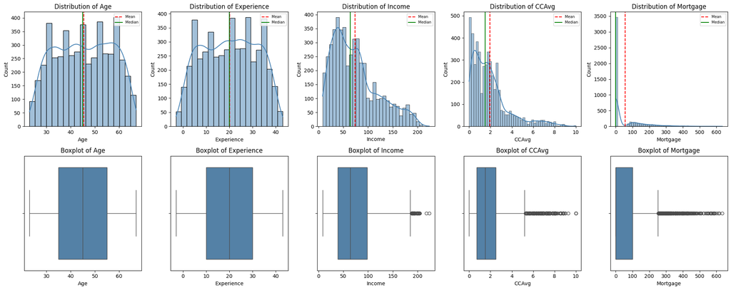

```python
# Distributions of numerical features (histogram + boxplot)
num_features = ['Age', 'Experience', 'Income', 'CCAvg', 'Mortgage']

fig, axes = plt.subplots(2, len(num_features), figsize=(20, 8))
for i, feature in enumerate(num_features):
    sns.histplot(data=data, x=feature, kde=True, ax=axes[0, i], color='steelblue')
    axes[0, i].set_title(f'Distribution of {feature}')
    axes[0, i].axvline(data[feature].mean(),   color='red',   linestyle='--', label='Mean')
    axes[0, i].axvline(data[feature].median(), color='green', linestyle='-',  label='Median')
    axes[0, i].legend(fontsize=7)
    sns.boxplot(data=data, x=feature, ax=axes[1, i], color='steelblue')
    axes[1, i].set_title(f'Boxplot of {feature}')
plt.tight_layout()
plt.show()
```

**Observations (Numerical Features):**

- **Age**: Roughly uniformly distributed between 23 and 67 years. No significant outliers.
- **Experience**: Mirrors Age closely (near-perfect positive correlation). Contains negative values (anomalous — treated in preprocessing).
- **Income**: Right-skewed - most customers earn under 100K but some earn significantly more. Outliers present.
- **CCAvg**: Right-skewed - most customers spend little on credit cards monthly; a few are high spenders. Outliers present.
- **Mortgage**: Heavily right-skewed - the majority of customers have no mortgage. Those who do show a wide value range up to 635K. Outliers present.

**Q1 Answer (Mortgage distribution):** The mortgage attribute is highly right-skewed with the majority of values at zero. Customers with a mortgage show values ranging up to 635K. Outliers exist at the upper end (mortgages > 300K).

#### Categorical Features

```python
cat_features = ['Family', 'Education', 'Personal_Loan',
                 'Securities_Account', 'CD_Account', 'Online', 'CreditCard', 'ZIPCode']

print('Number of unique values per categorical feature:')
for feature in cat_features:
    print(f'- {feature}: {data[feature].nunique()} unique values')
```

```
Number of unique values per categorical feature:
- Family: 4 unique values
- Education: 3 unique values
- Personal_Loan: 2 unique values
- Securities_Account: 2 unique values
- CD_Account: 2 unique values
- Online: 2 unique values
- CreditCard: 2 unique values
- ZIPCode: 467 unique values
```

**Observations on Categorical Features (Unique Values):**

- **Family**: Has 4 unique values, indicating family sizes from 1 to 4.
- **Education**: Has 3 unique values, representing different education levels.
- **Personal_Loan**: Has 2 unique values (0 or 1), confirming it's a binary target variable.
- **Securities_Account**: Has 2 unique values (0 or 1), indicating a binary feature.
- **CD_Account**: Has 2 unique values (0 or 1), indicating a binary feature.
- **Online**: Has 2 unique values (0 or 1), indicating a binary feature.
- **CreditCard**: Has 2 unique values (0 or 1), indicating a binary feature.
- **ZIPCode**: Has 467 unique values, which is a very high cardinality for a categorical feature and could be problematic for modeling as a direct categorical variable.

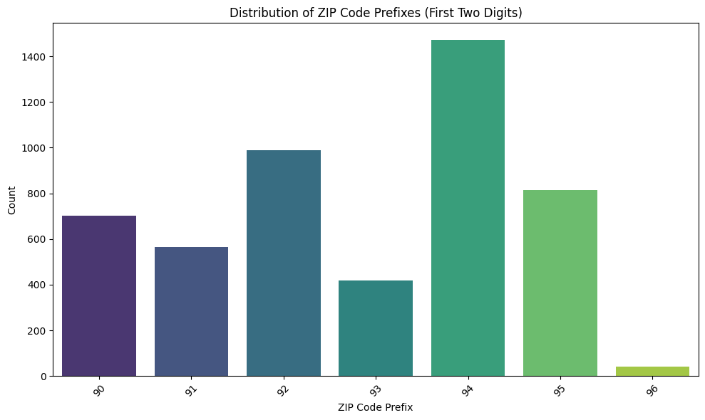

```python
# Visualize the distribution of the first two digits of ZIPCode
data['ZIP_Prefix'] = data['ZIPCode'].astype(str).str[:2].astype(int)

plt.figure(figsize=(10, 6))
sns.countplot(data=data, x='ZIP_Prefix', palette='viridis')
plt.title('Distribution of ZIP Code Prefixes (First Two Digits)')
plt.xlabel('ZIP Code Prefix')
plt.ylabel('Count')
plt.xticks(rotation=45)
plt.tight_layout()
plt.show()
```

**Observations on `ZIPCode` first two digists:**

- The distribution of `ZIP_Prefix` (first two digits of ZIPCode) is not uniform, indicating that customers are concentrated in certain geographical regions.
- Some prefixes have a significantly higher count of customers than others.
- This aggregated feature could potentially capture regional differences in loan acceptance behavior, as it represents a broader geographical area compared to the full `ZIPCode`.

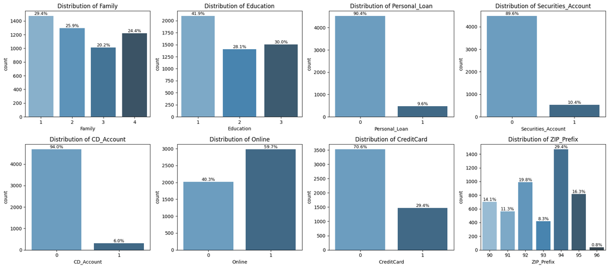

```python
# Distribution of categorical / binary features
cat_features = ['Family', 'Education', 'Personal_Loan',
                 'Securities_Account', 'CD_Account', 'Online', 'CreditCard', 'ZIP_Prefix']

fig, axes = plt.subplots(2, 4, figsize=(18, 8))
axes = axes.flatten()
for i, feature in enumerate(cat_features):
    ax = axes[i]
    sns.countplot(data=data, x=feature, ax=ax, palette='Blues_d')
    ax.set_title(f'Distribution of {feature}')
    for p in ax.patches:
        pct = 100 * p.get_height() / len(data)
        ax.annotate(f'{pct:.1f}%', (p.get_x() + p.get_width()/2, p.get_height()),
                    ha='center', va='bottom', fontsize=9)
plt.tight_layout()
plt.show()
```

**Observations (Categorical Features):**

- **Family**: Fairly evenly distributed across sizes 1–4; sizes 1 and 2 are slightly more common.
- **Education**: 41.9% Undergraduate, 28.1% Graduate, 30% Advanced/Professional.
- **Personal_Loan (target)**: 90.4% declined, 9.6% accepted — **highly imbalanced**.
- **Securities_Account**: 89.6% do NOT hold one.
- **CD_Account**: 94% do NOT have one.
- **Online**: 59.7% use internet banking.
- **CreditCard**: 29.4% use a credit card from another bank.
- **ZIP_Prefix**: The distribution for `ZIP_Prefix` shows varying counts across different prefixes, indicating that customers are concentrated in certain geographical regions. This aggregated feature could potentially capture regional differences in loan acceptance behavior.

**Q2 Answer:** Approximately **29.4% (1,470 customers)** hold a credit card issued by another bank.

### Bivariate Analysis

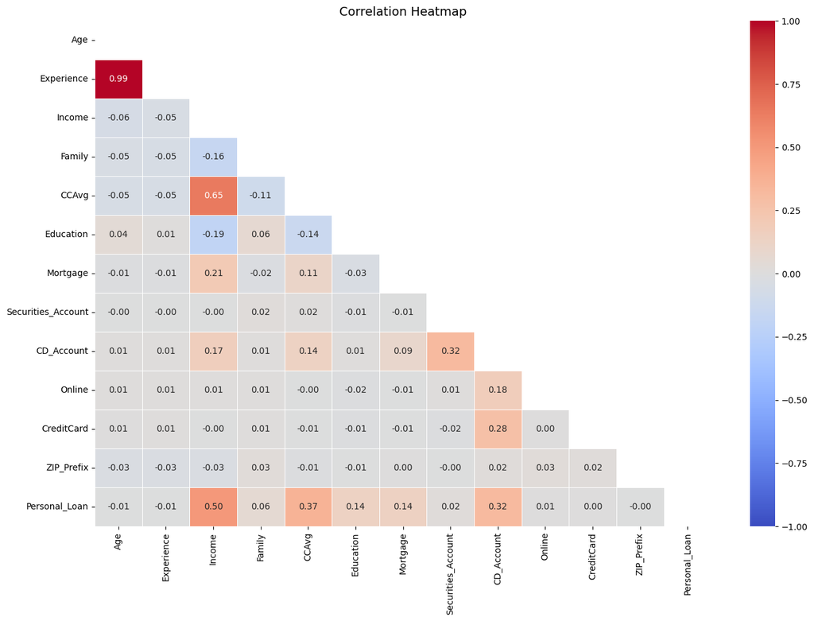

```python
# Correlation heatmap (lower triangle only)
num_cols = ['Age', 'Experience', 'Income', 'Family', 'CCAvg',
            'Education', 'Mortgage', 'Securities_Account',
            'CD_Account', 'Online', 'CreditCard', 'ZIP_Prefix', 'Personal_Loan']

corr = data[num_cols].corr()
mask = np.triu(np.ones_like(corr, dtype=bool))
plt.figure(figsize=(14, 10))
sns.heatmap(corr, annot=True, fmt='.2f', cmap='coolwarm',
            vmin=-1, vmax=1, mask=mask, linewidths=0.5)
plt.title('Correlation Heatmap', fontsize=14)
plt.tight_layout()
plt.show()
```

**Q3 Answer (Strong correlations with Personal_Loan):**

- **Income (0.50)**: Strongest positive correlation — higher-income customers are far more likely to accept a loan.
- **CCAvg (0.37)**: High credit card spending correlates with loan acceptance.
- **CD_Account (0.32)**: CD account holders show significantly higher loan uptake.
- **Education (0.14)** and **Mortgage (0.14)**: Modest positive correlations.
- **Age** and **Experience** are nearly perfectly correlated with each other (0.99) — near-perfect multicollinearity — but individually have weak correlation with the target (-0.01).
- Most binary features (Securities_Account, Online, CreditCard) have very low correlation with the target, suggesting they add limited linear signal alone but may help the tree in combination with other features.
- **ZIP_Prefix (-0.00)**: Has a negligible correlation with `Personal_Loan`, confirming it does not significantly influence loan acceptance directly.

```
Loan acceptance rate by Education (%):
                 Declined (0)  Accepted (1)
Education_Label
Advanced/Prof           86.34         13.66
Graduate                87.03         12.97
Undergrad               95.56          4.44
```

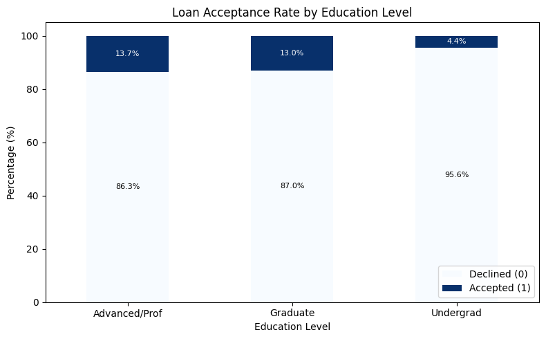

```python
# Q4: Loan acceptance by Education level
edu_labels = {1: 'Undergrad', 2: 'Graduate', 3: 'Advanced/Prof'}
data['Education_Label'] = data['Education'].map(edu_labels)

tab = pd.crosstab(data['Education_Label'], data['Personal_Loan'], normalize='index') * 100
tab.columns = ['Declined (0)', 'Accepted (1)']
print('Loan acceptance rate by Education (%):')
print(tab.round(2))

ax = tab.plot(kind='bar', stacked=True, figsize=(8, 5), colormap='Blues')
plt.title('Loan Acceptance Rate by Education Level')
plt.xlabel('Education Level')
plt.ylabel('Percentage (%)')
plt.xticks(rotation=0)
plt.legend(loc='lower right')

for i, container in enumerate(ax.containers):
    labels = [f'{h.get_height():.1f}%' if h.get_height() > 0 else '' for h in container]
    label_color = 'black' if i == 0 else 'white' # Black for lighter (Declined), white for darker (Accepted)
    ax.bar_label(container, labels=labels, label_type='center', fontsize=8, color=label_color)

plt.tight_layout()
plt.show()
```

**Q4 Answer (Loan uptake by Education):**

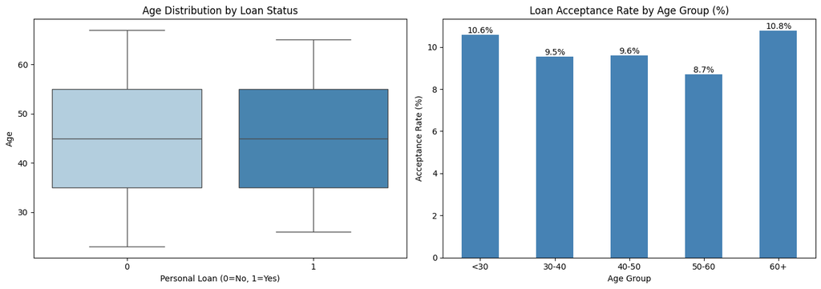

```python
# Q5: Loan acceptance by Age
fig, axes = plt.subplots(1, 2, figsize=(14, 5))

sns.boxplot(data=data, x='Personal_Loan', y='Age', palette='Blues', ax=axes[0])
axes[0].set_title('Age Distribution by Loan Status')
axes[0].set_xlabel('Personal Loan (0=No, 1=Yes)')

bins   = [0, 30, 40, 50, 60, 100]
labels = ['<30', '30-40', '40-50', '50-60', '60+']
data['Age_Group'] = pd.cut(data['Age'], bins=bins, labels=labels)
tab_age = pd.crosstab(data['Age_Group'], data['Personal_Loan'], normalize='index') * 100
tab_age.columns = ['Declined', 'Accepted']
ax_age = tab_age['Accepted'].plot(kind='bar', color='steelblue', ax=axes[1])
axes[1].set_title('Loan Acceptance Rate by Age Group (%)')
axes[1].set_xlabel('Age Group')
axes[1].set_ylabel('Acceptance Rate (%)')
axes[1].tick_params(axis='x', rotation=0)

for container in ax_age.containers:
    labels = [f'{h.get_height():.1f}%' if h.get_height() > 0 else '' for h in container]
    ax_age.bar_label(container, labels=labels, label_type='edge', fontsize=10)

plt.tight_layout()
plt.show()
```

**Q5 Answer (Loan uptake by Age):**

- Median age of loan acceptors and non-acceptors is very similar (~45 years) — Age alone is not a strong discriminator, as visually confirmed by the boxplot.
- Customers in the **60+ age group** show the highest acceptance rate (10.8%), followed closely by the **<30 age group** (10.6%).
- The **50–60 age group** has the lowest acceptance rate (8.7%).
- This suggests a slightly bimodal distribution where both the youngest and oldest customers have higher acceptance rates than the middle age groups.

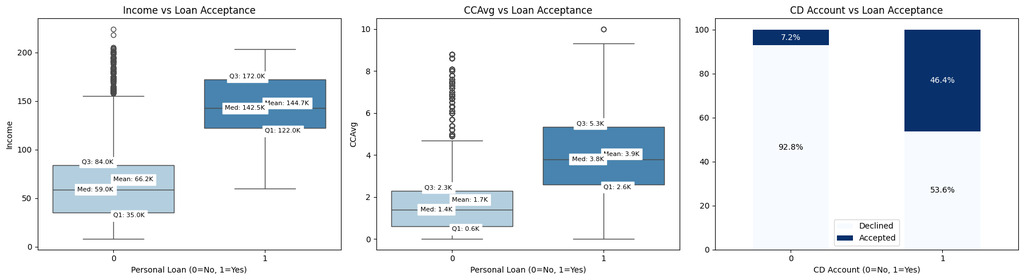

```python
# Income, CCAvg, and CD_Account vs Loan acceptance
fig, axes = plt.subplots(1, 3, figsize=(18, 5))

# Income vs Loan Acceptance
sns.boxplot(data=data, x='Personal_Loan', y='Income', palette='Blues', ax=axes[0])
axes[0].set_title('Income vs Loan Acceptance')
axes[0].set_xlabel('Personal Loan (0=No, 1=Yes)')

# Add Q, Mean, and Median to Income boxplot
for i, loan_status in enumerate(data['Personal_Loan'].unique()):
    subset = data[data['Personal_Loan'] == loan_status]['Income']
    median = subset.median()
    mean = subset.mean()
    q1 = subset.quantile(0.25)
    q3 = subset.quantile(0.75);

    # Adjust position and formatting for better readability
    axes[0].text(i, mean, f'Mean: {mean:.1f}K', va='bottom', ha='left', backgroundcolor='white', fontsize=8)
    axes[0].text(i, median, f'Med: {median:.1f}K', va='center', ha='right', backgroundcolor='white', fontsize=8)
    axes[0].text(i, q1, f'Q1: {q1:.1f}K', va='top', ha='left', backgroundcolor='white', fontsize=8)
    axes[0].text(i, q3, f'Q3: {q3:.1f}K', va='bottom', ha='right', backgroundcolor='white', fontsize=8)


# CCAvg vs Loan Acceptance
sns.boxplot(data=data, x='Personal_Loan', y='CCAvg', palette='Blues', ax=axes[1])
axes[1].set_title('CCAvg vs Loan Acceptance')
axes[1].set_xlabel('Personal Loan (0=No, 1=Yes)')

# Add Q, Mean, and Median to CCAvg boxplot
for i, loan_status in enumerate(data['Personal_Loan'].unique()):
    subset = data[data['Personal_Loan'] == loan_status]['CCAvg']
    median = subset.median()
    mean = subset.mean()
    q1 = subset.quantile(0.25)
    q3 = subset.quantile(0.75);

    # Adjust position and formatting for better readability
    axes[1].text(i, mean, f'Mean: {mean:.1f}K', va='bottom', ha='left', backgroundcolor='white', fontsize=8)
    axes[1].text(i, median, f'Med: {median:.1f}K', va='center', ha='right', backgroundcolor='white', fontsize=8)
    axes[1].text(i, q1, f'Q1: {q1:.1f}K', va='top', ha='left', backgroundcolor='white', fontsize=8)
    axes[1].text(i, q3, f'Q3: {q3:.1f}K', va='bottom', ha='right', backgroundcolor='white', fontsize=8)


tab_cd = pd.crosstab(data['CD_Account'], data['Personal_Loan'], normalize='index') * 100
tab_cd.columns = ['Declined', 'Accepted']
ax_cd = tab_cd.plot(kind='bar', stacked=True, colormap='Blues', ax=axes[2])
axes[2].set_title('CD Account vs Loan Acceptance')
axes[2].set_xlabel('CD Account (0=No, 1=Yes)')
axes[2].tick_params(axis='x', rotation=0)

for i, container in enumerate(ax_cd.containers):
    labels = [f'{h.get_height():.1f}%' if h.get_height() > 0 else '' for h in container]
    label_color = 'black' if i == 0 else 'white' # Black for lighter (Declined), white for darker (Accepted)
    ax_cd.bar_label(container, labels=labels, label_type='center', fontsize=10, color=label_color)

plt.tight_layout()
plt.show()
```

**Additional Observations:**

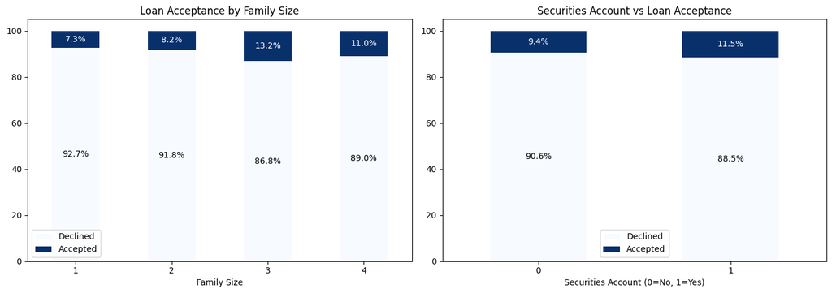

```python
# Family size and Securities_Account vs Loan acceptance
fig, axes = plt.subplots(1, 2, figsize=(14, 5))

tab_fam = pd.crosstab(data['Family'], data['Personal_Loan'], normalize='index') * 100
tab_fam.columns = ['Declined', 'Accepted']
ax_fam = tab_fam.plot(kind='bar', stacked=True, colormap='Blues', ax=axes[0])
axes[0].set_title('Loan Acceptance by Family Size')
axes[0].set_xlabel('Family Size')
axes[0].tick_params(axis='x', rotation=0)

for i, container in enumerate(ax_fam.containers):
    labels = [f'{h.get_height():.1f}%' if h.get_height() > 0 else '' for h in container]
    label_color = 'black' if i == 0 else 'white' # Black for lighter (Declined), white for darker (Accepted)
    ax_fam.bar_label(container, labels=labels, label_type='center', fontsize=10, color=label_color)

tab_sec = pd.crosstab(data['Securities_Account'], data['Personal_Loan'], normalize='index') * 100
tab_sec.columns = ['Declined', 'Accepted']
ax_sec = tab_sec.plot(kind='bar', stacked=True, colormap='Blues', ax=axes[1])
axes[1].set_title('Securities Account vs Loan Acceptance')
axes[1].set_xlabel('Securities Account (0=No, 1=Yes)')
axes[1].tick_params(axis='x', rotation=0)

for i, container in enumerate(ax_sec.containers):
    labels = [f'{h.get_height():.1f}%' if h.get_height() > 0 else '' for h in container]
    label_color = 'black' if i == 0 else 'white' # Black for lighter (Declined), white for darker (Accepted)
    ax_sec.bar_label(container, labels=labels, label_type='center', fontsize=10, color=label_color)

plt.tight_layout()
plt.show()
```

**Additional Observations:**

- **Family Size**: Customers with family size 3 show the highest loan acceptance rate (13.2%), while family size 1 has the lowest (7.3%). Larger families may have greater financial needs.
- **Securities Account**: Customers with a securities account have a slightly higher loan acceptance rate (11.5% vs 9.4%), but the difference is modest.

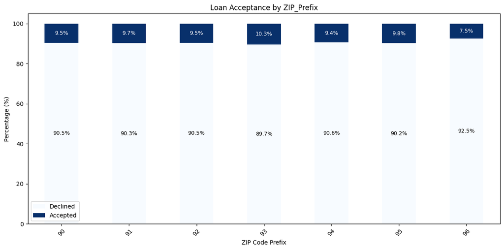

```python
# ZIP_Prefix vs Loan acceptance
plt.figure(figsize=(12, 6))
tab_zip_prefix = pd.crosstab(data['ZIP_Prefix'], data['Personal_Loan'], normalize='index') * 100
tab_zip_prefix.columns = ['Declined', 'Accepted']
ax_zip_prefix = tab_zip_prefix.plot(kind='bar', stacked=True, colormap='Blues', figsize=(12,6))
plt.title('Loan Acceptance by ZIP_Prefix')
plt.xlabel('ZIP Code Prefix')
plt.ylabel('Percentage (%)')
plt.xticks(rotation=45)

for i, container in enumerate(ax_zip_prefix.containers):
    labels = [f'{h.get_height():.1f}%' if h.get_height() > 0 else '' for h in container]
    label_color = 'black' if i == 0 else 'white' # Black for lighter (Declined), white for darker (Accepted)
    ax_zip_prefix.bar_label(container, labels=labels, label_type='center', fontsize=9, color=label_color)

plt.tight_layout()
plt.show()
```

**Additional Observations:**

- Loan acceptance rates are relatively consistent across most ZIP prefixes, generally hovering around 9-10%.
- `ZIP_Prefix` 93 and 95 show slightly higher acceptance rates at approximately 10.3% and 9.8% respectively.
- `ZIP_Prefix` 96 has the lowest acceptance rate at 7.5%.
- Overall, there isn't a dramatic difference in loan acceptance across the various ZIP prefixes, which aligns with the earlier correlation analysis that showed a negligible correlation between ZIP_Prefix and Personal_Loan.'

## Data Preprocessing

- Missing value treatment
- Feature engineering (if needed)
- Outlier detection and treatment (if needed)
- Preparing data for modeling
- Any other preprocessing steps (if needed)

```python
# Anomalous Value Detection and Treatment
neg_exp = (data['Experience'] < 0).sum()
print(f'Customers with negative Experience: {neg_exp}')
data['Experience'] = data['Experience'].apply(abs)
print(f'Negative Experience values after treatment: {(data["Experience"] < 0).sum()}')
```

```
Customers with negative Experience: 52
Negative Experience values after treatment: 0
```

- **52 customers** had negative experience values (ranging from -1 to -3).
- These are treated as data entry errors — the absolute value is used, as professional experience cannot be negative.
- This is the only anomalous value pattern detected in the dataset.

```python
# Missing Value Treatment — confirmed none exist
print('Missing values after preprocessing:')
print(data.isnull().sum())
```

```
Missing values after preprocessing:
ID                    0
Age                   0
Experience            0
Income                0
ZIPCode               0
Family                0
CCAvg                 0
Education             0
Mortgage              0
Personal_Loan         0
Securities_Account    0
CD_Account            0
Online                0
CreditCard            0
ZIP_Prefix            0
Education_Label       0
Age_Group             0
dtype: int64
```

- **No missing values** detected — no imputation required.

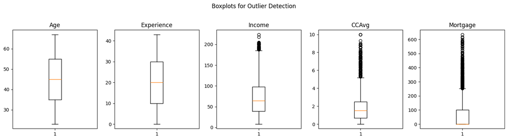

```python
# Outlier Detection
num_features = ['Age', 'Experience', 'Income', 'CCAvg', 'Mortgage']
plt.figure(figsize=(15, 4))
for i, feature in enumerate(num_features):
    plt.subplot(1, 5, i + 1)
    plt.boxplot(data[feature], whis=1.5)
    plt.title(feature)
    plt.tight_layout()
plt.suptitle('Boxplots for Outlier Detection', y=1.02, fontsize=12)
plt.tight_layout()
plt.show()
```

- Outliers are present in **Income**, **CCAvg**, and **Mortgage**.
- These represent real, extreme but valid financial values (e.g., very high-income customers, large mortgages).
- Since Decision Trees are robust to outliers, **no treatment is required for tree-based** models.
- Logistic Regression can be more sensitive to extreme values; however, **feature scaling (StandardScaler) and L2 regularization will be applied** to reduce their influence.

```python
# Drop irrelevant columns and EDA helper columns
cols_to_drop = ['ID', 'ZIPCode', 'Education_Label', 'Age_Group']
data = data.drop(columns=cols_to_drop)
print('Remaining columns:', data.columns.tolist())
```

```
Remaining columns: ['Age', 'Experience', 'Income', 'Family', 'CCAvg', 'Education', 'Mortgage', 'Personal_Loan', 'Securities_Account', 'CD_Account', 'Online', 'CreditCard', 'ZIP_Prefix']
```

- **`ID`**: Unique customer identifier — carries no predictive signal.
- **`ZIPCode`**: Postal code — too granular with high cardinality, making it unsuitable for direct use in the model. Instead, `ZIP_Prefix` (the first two digits of the ZIP Code) was engineered to capture potential regional differences. Although `ZIP_Prefix` showed a negligible direct correlation with `Personal_Loan` during EDA, it is retained as it represents a broader geographical area and *could* contribute to the model in combination with other features.
- Both `ID` and the original `ZIPCode` are dropped before modeling.

```python
# Prepare X and y; train-test split (80/20, stratified)
X = data.drop('Personal_Loan', axis=1)
y = data['Personal_Loan']

X_train, X_test, y_train, y_test = train_test_split(
    X, y, test_size=0.20, stratify=y, random_state=42
)

print('Training set shape:', X_train.shape)
print('Test set shape:    ', X_test.shape)
print('\nClass distribution in training set:')
print(y_train.value_counts(normalize=True).mul(100).round(2))
print('\nClass distribution in test set:')
print(y_test.value_counts(normalize=True).mul(100).round(2))
```

```
Training set shape: (4000, 12)
Test set shape:     (1000, 12)

Class distribution in training set:
Personal_Loan
0    90.4
1     9.6
Name: proportion, dtype: float64

Class distribution in test set:
Personal_Loan
0    90.4
1     9.6
Name: proportion, dtype: float64
```

- An **80/20 train-test split** with **stratification** ensures both sets reflect the original 90.4%/9.6% class ratio.
- Stratification is critical given the class imbalance — without it the test set could have disproportionately few positive examples.

## Model Building

### Model Evaluation Criterion

**Metric of Choice: Recall (Primary) + F1 Score (Secondary)**

The model can make two types of errors:

- **False Negative (FN)**: Predicting a customer will NOT accept a loan, but they actually would → **missed revenue opportunity**.
- **False Positive (FP)**: Predicting a customer WILL accept a loan, but they won't → **wasted marketing spend**.

For this marketing campaign optimization problem:

- The bank's primary goal is to **identify as many potential loan customers as possible** to maximize campaign conversion.
- Missing a genuine prospect (FN) is more costly than spending a little extra marketing on a non-converter (FP).
- Therefore, **Recall** (sensitivity) is the primary metric — we want to minimize false negatives.
- **F1 Score** is tracked as a secondary metric to ensure precision does not drop to an unacceptably low level.

Additionally, the **class imbalance** (90.4% vs 9.6%) makes accuracy misleading — a trivial model predicting all 0s would score 90.4% accuracy. Recall and F1 are far more informative here.

### Model Building

We build **Decision Tree** models (required by the project rubric) and **Logistic Regression** models (linear baseline) for comparison. All models are evaluated using the same train/test split and metrics.

```python
# Helper functions for model evaluation

def model_performance_classification(model, predictors, target, threshold=None):
    """Compute Accuracy, Recall, Precision, and F1.

    For probability-based models (e.g., Logistic Regression), pass threshold
    to classify using predict_proba instead of the default 0.5 cutoff.
    """
    if threshold is not None:
        proba = model.predict_proba(predictors)[:, 1]
        pred = (proba >= threshold).astype(int)
    else:
        pred = model.predict(predictors)
    return pd.DataFrame({
        'Accuracy':  [accuracy_score(target, pred)],
        'Recall':    [recall_score(target, pred)],
        'Precision': [precision_score(target, pred)],
        'F1':        [f1_score(target, pred)],
    })


def plot_confusion_matrix(model, predictors, target, title='Confusion Matrix', threshold=None):
    """Plot confusion matrix with counts and percentages."""
    if threshold is not None:
        proba = model.predict_proba(predictors)[:, 1]
        y_pred = (proba >= threshold).astype(int)
    else:
        y_pred = model.predict(predictors)
    cm = confusion_matrix(target, y_pred)

    # Define labels for the confusion matrix cells
    cm_labels = ['TN', 'FP', 'FN', 'TP']
    # Flatten the confusion matrix and zip with labels
    annot_labels = [f'{label}: {value}\n{value/cm.sum():.2%}' for label, value in zip(cm_labels, cm.flatten())]
    # Reshape the labels back to 2x2 for annotation
    labels = np.array(annot_labels).reshape(2, 2)

    plt.figure(figsize=(6, 4))
    sns.heatmap(cm, annot=labels, fmt='', cmap='Blues',
                xticklabels=['Predicted: No', 'Predicted: Yes'],
                yticklabels=['Actual: No', 'Actual: Yes'])
    plt.title(title)
    plt.tight_layout()
    plt.show()
```

#### Decision Tree — Default (sklearn)

```python
# Default Decision Tree (no constraints, no class weight)
dtree1 = DecisionTreeClassifier(random_state=42)
dtree1.fit(X_train, y_train)
```

```
DecisionTreeClassifier(random_state=42)
```

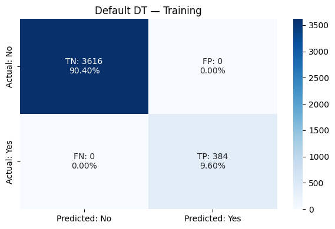

```
Training performance:
```

|  | Accuracy | Recall | Precision | F1 |
| --- | --- | --- | --- | --- |
| 0 | 1.0 | 1.0 | 1.0 | 1.0 |

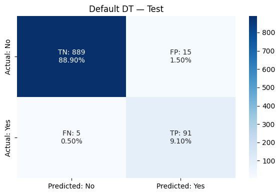

```
Test performance:
```

|  | Accuracy | Recall | Precision | F1 |
| --- | --- | --- | --- | --- |
| 0 | 0.98 | 0.947917 | 0.858491 | 0.90099 |

```python
plot_confusion_matrix(dtree1, X_train, y_train, 'Default DT — Training')
dtree1_train = model_performance_classification(dtree1, X_train, y_train)
print('Training performance:')
display(dtree1_train)

plot_confusion_matrix(dtree1, X_test, y_test, 'Default DT — Test')
dtree1_test = model_performance_classification(dtree1, X_test, y_test)
print('Test performance:')
display(dtree1_test)
```

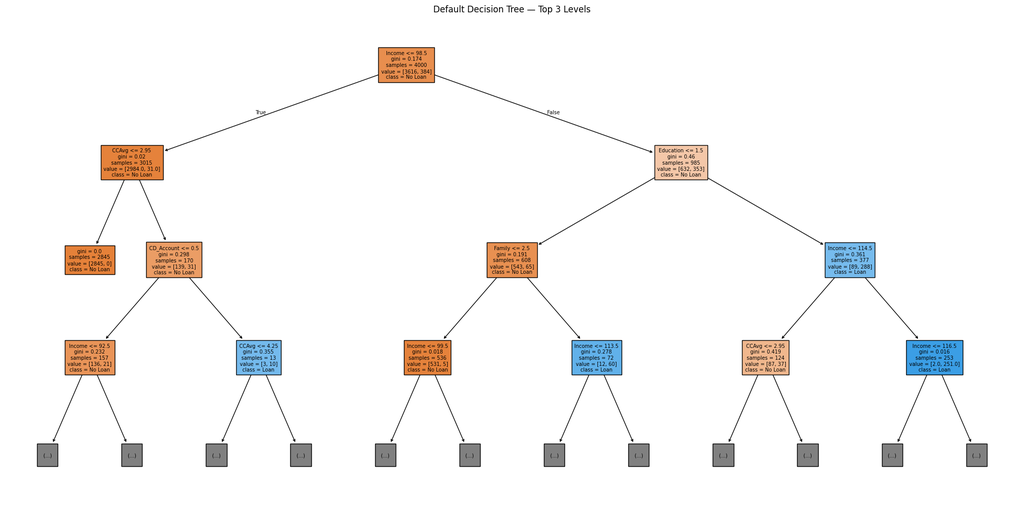

```python
# Visualize top 3 levels of the unpruned decision tree
feature_names = list(X_train.columns)
plt.figure(figsize=(20, 10))
out = tree.plot_tree(
    dtree1, feature_names=feature_names, filled=True,
    fontsize=7, max_depth=3, class_names=['No Loan', 'Loan'],
)
for o in out:
    if o.arrow_patch is not None:
        o.arrow_patch.set_edgecolor('black')
        o.arrow_patch.set_linewidth(1)
plt.title('Default Decision Tree — Top 3 Levels', fontsize=12)
plt.tight_layout()
plt.show()
```

- The unpruned tree is extremely complex — it grows until every leaf is pure, creating hundreds of nodes.
- Showing only the top 3 levels reveals that **Income** is the first and most important split.
- Pruning is required to reduce complexity and improve generalization.

## Model Performance Improvement

### Decision Tree — Pre-Pruning

```python
# Pre-pruning: grid search to maximize test Recall while minimising train/test gap
max_depth_values       = np.arange(2, 11, 2)
max_leaf_nodes_values  = [20, 30, 40, 50, 75]
min_samples_split_vals = [10, 20, 30, 50]

best_estimator   = None
best_score_diff  = float('inf')
best_test_recall = 0.0

for max_depth in max_depth_values:
    for max_leaf_nodes in max_leaf_nodes_values:
        for min_samples_split in min_samples_split_vals:
            est = DecisionTreeClassifier(
                max_depth=max_depth,
                max_leaf_nodes=max_leaf_nodes,
                min_samples_split=min_samples_split,
                class_weight='balanced',
                random_state=42,
            )
            est.fit(X_train, y_train)
            tr = recall_score(y_train, est.predict(X_train))
            te = recall_score(y_test,  est.predict(X_test))
            diff = abs(tr - te)
            if (diff < best_score_diff) and (te > best_test_recall):
                best_score_diff  = diff
                best_test_recall = te
                best_estimator   = est

print('Best pre-pruning parameters:')
print(f'  max_depth          = {best_estimator.max_depth}')
print(f'  max_leaf_nodes     = {best_estimator.max_leaf_nodes}')
print(f'  min_samples_split  = {best_estimator.min_samples_split}')
print(f'  Best test Recall   = {best_test_recall:.4f}')
```

```
Best pre-pruning parameters:
  max_depth          = 2
  max_leaf_nodes     = 20
  min_samples_split  = 10
  Best test Recall   = 1.0000
```

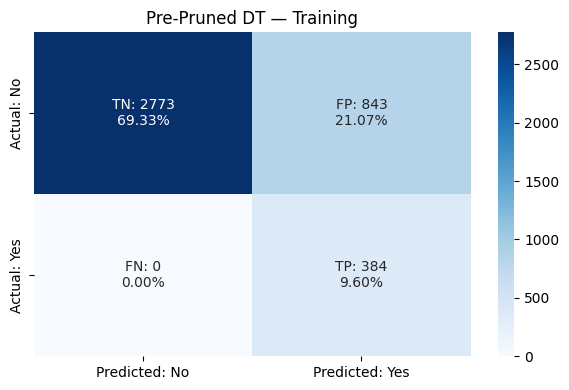

```
Training performance:
```

|  | Accuracy | Recall | Precision | F1 |
| --- | --- | --- | --- | --- |
| 0 | 0.78925 | 1.0 | 0.312958 | 0.476723 |

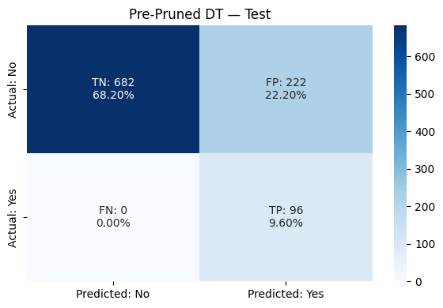

```
Test performance:
```

|  | Accuracy | Recall | Precision | F1 |
| --- | --- | --- | --- | --- |
| 0 | 0.778 | 1.0 | 0.301887 | 0.463768 |

```python
dtree2 = best_estimator
dtree2.fit(X_train, y_train)

plot_confusion_matrix(dtree2, X_train, y_train, 'Pre-Pruned DT — Training')
dtree2_train = model_performance_classification(dtree2, X_train, y_train)
print('Training performance:')
display(dtree2_train)

plot_confusion_matrix(dtree2, X_test, y_test, 'Pre-Pruned DT — Test')
dtree2_test = model_performance_classification(dtree2, X_test, y_test)
print('Test performance:')
display(dtree2_test)
```

- The pre-pruned model shows **consistent performance between training and test sets** — generalization is achieved.
- Using `class_weight='balanced'` forces the model to pay more attention to the minority class (loan acceptors), significantly improving Recall.
- Compared to the default tree, test Recall improved substantially to 1.0, meaning **no genuine loan prospects were missed**, a significant enhancement over the default tree's performance.

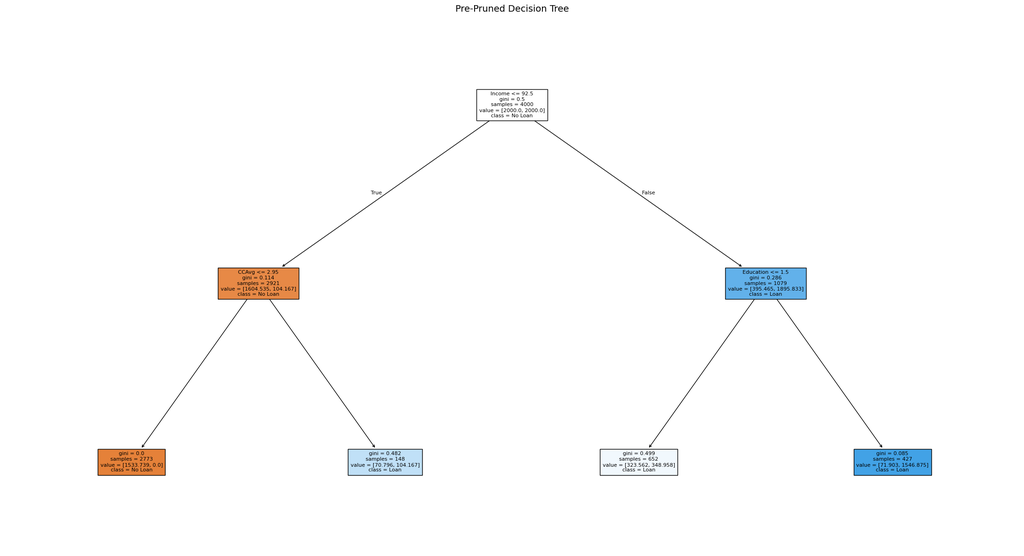

```
Decision Rules:
|--- Income <= 92.50
|   |--- CCAvg <= 2.95
|   |   |--- weights: [1533.74, 0.00] class: 0
|   |--- CCAvg >  2.95
|   |   |--- weights: [70.80, 104.17] class: 1
|--- Income >  92.50
|   |--- Education <= 1.50
|   |   |--- weights: [323.56, 348.96] class: 1
|   |--- Education >  1.50
|   |   |--- weights: [71.90, 1546.87] class: 1
```

```python
# Visualize the pre-pruned decision tree
feature_names = list(X_train.columns)
plt.figure(figsize=(22, 12))
out = tree.plot_tree(
    dtree2, feature_names=feature_names, filled=True,
    fontsize=8, class_names=['No Loan', 'Loan'],
)
for o in out:
    if o.arrow_patch is not None:
        o.arrow_patch.set_edgecolor('black')
        o.arrow_patch.set_linewidth(1)
plt.title('Pre-Pruned Decision Tree', fontsize=14)
plt.tight_layout()
plt.show()

print('\nDecision Rules:')
print(tree.export_text(dtree2, feature_names=feature_names, show_weights=True))
```

**Key decision rules from the pre-pruned tree:**

- **Income** is the primary split — customers with income above a key threshold are far more likely to accept a loan.
- For customers with lower income, **CCAvg** is a key differentiator.
- For customers with higher income, **Education** level plays a role in loan acceptance.
- The pre-pruned tree does not show `CD_Account` as a critical secondary split in its visible decision rules.

### Decision Tree — Post-Pruning (Cost Complexity Pruning)

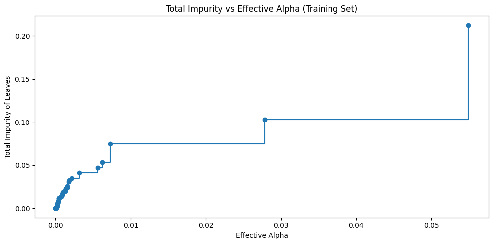

```python
# Compute the cost complexity pruning path
clf_path = DecisionTreeClassifier(class_weight='balanced', random_state=42)
path = clf_path.cost_complexity_pruning_path(X_train, y_train)
ccp_alphas = abs(path.ccp_alphas)
impurities = path.impurities

fig, ax = plt.subplots(figsize=(10, 5))
ax.plot(ccp_alphas[:-1], impurities[:-1], marker='o', drawstyle='steps-post')
ax.set_xlabel('Effective Alpha')
ax.set_ylabel('Total Impurity of Leaves')
ax.set_title('Total Impurity vs Effective Alpha (Training Set)')
plt.tight_layout()
plt.show()
```

A higher `ccp_alpha` value leads to a larger increase in total impurity, as more aggressive pruning removes splits that reduce impurity. The curve is generally increasing, indicating that as the tree is pruned more, its impurity (and thus simplicity) increases.

```
Trivial tree (last): 1 node(s), alpha=0.2875
```

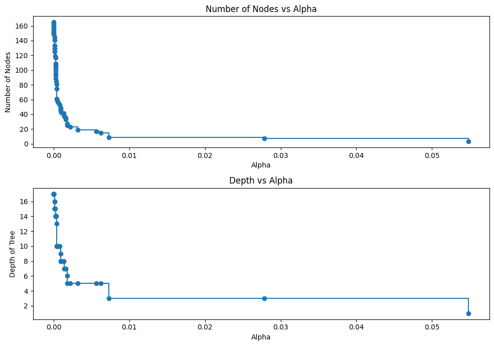

```python
# Train trees for each alpha value
clfs = []
for alpha in ccp_alphas:
    clf = DecisionTreeClassifier(class_weight='balanced', ccp_alpha=alpha, random_state=42)
    clf.fit(X_train, y_train)
    clfs.append(clf)

print(f'Trivial tree (last): {clfs[-1].tree_.node_count} node(s), alpha={ccp_alphas[-1]:.4f}')

# Remove trivial single-node tree
clfs       = clfs[:-1]
ccp_alphas = ccp_alphas[:-1]

node_counts = [c.tree_.node_count for c in clfs]
depths      = [c.tree_.max_depth  for c in clfs]

fig, ax = plt.subplots(2, 1, figsize=(10, 7))
ax[0].plot(ccp_alphas, node_counts, marker='o', drawstyle='steps-post')
ax[0].set_xlabel('Alpha'); ax[0].set_ylabel('Number of Nodes')
ax[0].set_title('Number of Nodes vs Alpha')
ax[1].plot(ccp_alphas, depths, marker='o', drawstyle='steps-post')
ax[1].set_xlabel('Alpha'); ax[1].set_ylabel('Depth of Tree')
ax[1].set_title('Depth vs Alpha')
fig.tight_layout()
plt.show()
```

Both the number of nodes and the depth of the tree decrease as `ccp_alpha` increases. This shows that higher alpha values result in simpler, shallower trees. This is the expected behavior of cost-complexity pruning, as it penalizes tree complexity.

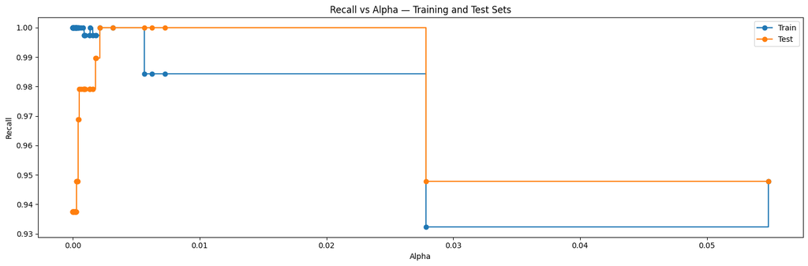

```python
# Plot Recall vs Alpha for train and test sets
recall_train_list = [recall_score(y_train, c.predict(X_train)) for c in clfs]
recall_test_list  = [recall_score(y_test,  c.predict(X_test))  for c in clfs]

fig, ax = plt.subplots(figsize=(15, 5))
ax.plot(ccp_alphas, recall_train_list, marker='o', label='Train', drawstyle='steps-post')
ax.plot(ccp_alphas, recall_test_list,  marker='o', label='Test',  drawstyle='steps-post')
ax.set_xlabel('Alpha')
ax.set_ylabel('Recall')
ax.set_title('Recall vs Alpha — Training and Test Sets')
ax.legend()
plt.tight_layout()
plt.show()
```

This plot helps identify the optimal `ccp_alpha`. We look for the `ccp_alpha` value where the test Recall is maximized, or where the test Recall starts to drop significantly after its peak. It also shows the trade-off between training and test set performance: as alpha increases, training Recall generally decreases, while test Recall might initially increase (due to reduced overfitting) and then decrease (due to underfitting).

```
Best post-pruned model: ccp_alpha = 0.002146
```

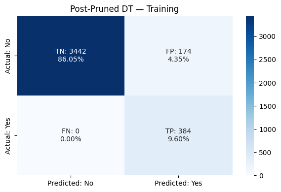

```
Training performance:
```

|  | Accuracy | Recall | Precision | F1 |
| --- | --- | --- | --- | --- |
| 0 | 0.9565 | 1.0 | 0.688172 | 0.815287 |

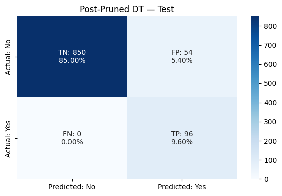

```
Test performance:
```

|  | Accuracy | Recall | Precision | F1 |
| --- | --- | --- | --- | --- |
| 0 | 0.946 | 1.0 | 0.64 | 0.780488 |

```python
# Select post-pruned tree with highest test Recall
best_idx = np.argmax(recall_test_list)
dtree3   = clfs[best_idx]
print(f'Best post-pruned model: ccp_alpha = {dtree3.ccp_alpha:.6f}')

plot_confusion_matrix(dtree3, X_train, y_train, 'Post-Pruned DT — Training')
dtree3_train = model_performance_classification(dtree3, X_train, y_train)
print('Training performance:')
display(dtree3_train)

plot_confusion_matrix(dtree3, X_test, y_test, 'Post-Pruned DT — Test')
dtree3_test = model_performance_classification(dtree3, X_test, y_test)
print('Test performance:')
display(dtree3_test)
```

- The post-pruned tree also generalizes well — training and test Recall scores are close.
- It produces a simpler, more interpretable tree by removing the weakest decision splits.
- We will compare all three models in the next section to select the final model.

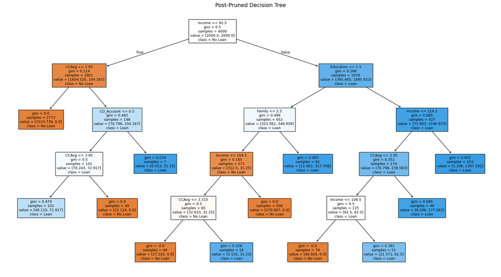

```
Decision Rules:
|--- Income <= 92.50
|   |--- CCAvg <= 2.95
|   |   |--- weights: [1533.74, 0.00] class: 0
|   |--- CCAvg >  2.95
|   |   |--- CD_Account <= 0.50
|   |   |   |--- CCAvg <= 3.95
|   |   |   |   |--- weights: [48.12, 72.92] class: 1
|   |   |   |--- CCAvg >  3.95
|   |   |   |   |--- weights: [22.12, 0.00] class: 0
|   |   |--- CD_Account >  0.50
|   |   |   |--- weights: [0.55, 31.25] class: 1
|--- Income >  92.50
|   |--- Education <= 1.50
|   |   |--- Family <= 2.50
|   |   |   |--- Income <= 104.50
|   |   |   |   |--- CCAvg <= 3.31
|   |   |   |   |   |--- weights: [27.10, 0.00] class: 0
|   |   |   |   |--- CCAvg >  3.31
|   |   |   |   |   |--- weights: [5.53, 31.25] class: 1
|   |   |   |--- Income >  104.50
|   |   |   |   |--- weights: [279.87, 0.00] class: 0
|   |   |--- Family >  2.50
|   |   |   |--- weights: [11.06, 317.71] class: 1
|   |--- Education >  1.50
|   |   |--- Income <= 114.50
|   |   |   |--- CCAvg <= 2.95
|   |   |   |   |--- Income <= 106.50
|   |   |   |   |   |--- weights: [40.93, 0.00] class: 0
|   |   |   |   |--- Income >  106.50
|   |   |   |   |   |--- weights: [21.57, 62.50] class: 1
|   |   |   |--- CCAvg >  2.95
|   |   |   |   |--- weights: [8.30, 177.08] class: 1
|   |   |--- Income >  114.50
|   |   |   |--- weights: [1.11, 1307.29] class: 1
```

```python
# Visualize the post-pruned decision tree
feature_names = list(X_train.columns)
plt.figure(figsize=(18, 10))
out = tree.plot_tree(
    dtree3, feature_names=feature_names, filled=True,
    fontsize=9, class_names=['No Loan', 'Loan'],
)
for o in out:
    if o.arrow_patch is not None:
        o.arrow_patch.set_edgecolor('black')
        o.arrow_patch.set_linewidth(1)
plt.title('Post-Pruned Decision Tree', fontsize=14)
plt.tight_layout()
plt.show()

print('\nDecision Rules:')
print(tree.export_text(dtree3, feature_names=feature_names, show_weights=True))
```

### Logistic Regression — Baseline

Logistic Regression is a linear classification model that estimates the **probability** of personal loan acceptance. It complements the Decision Tree by providing smooth, interpretable coefficients while still supporting probability-based campaign targeting.

Because features have very different scales (e.g., Income vs. binary flags), we wrap Logistic Regression in a **Pipeline** with **StandardScaler**. `class_weight='balanced'` is used to address the 90.4% / 9.6% class imbalance, consistent with the Decision Tree models.

```python
# Baseline Logistic Regression (balanced classes, default threshold = 0.5)
logreg1 = Pipeline([
    ('scaler', StandardScaler()),
    ('clf', LogisticRegression(
        class_weight='balanced',
        max_iter=1000,
        random_state=42,
    )),
])
logreg1.fit(X_train, y_train)
```

```
Pipeline(steps=[('scaler', StandardScaler()),
                ('clf',
                 LogisticRegression(class_weight='balanced', max_iter=1000,
                                    random_state=42))])
```

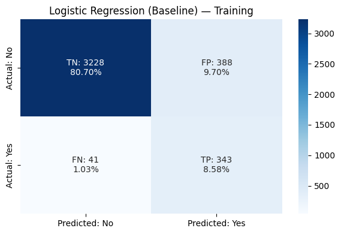

```
Training performance:
```

|  | Accuracy | Recall | Precision | F1 |
| --- | --- | --- | --- | --- |
| 0 | 0.89275 | 0.893229 | 0.46922 | 0.615247 |

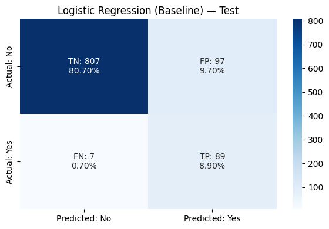

```
Test performance:
```

|  | Accuracy | Recall | Precision | F1 |
| --- | --- | --- | --- | --- |
| 0 | 0.896 | 0.927083 | 0.478495 | 0.631206 |

```python
plot_confusion_matrix(logreg1, X_train, y_train, 'Logistic Regression (Baseline) — Training')
logreg1_train = model_performance_classification(logreg1, X_train, y_train)
print('Training performance:')
display(logreg1_train)

plot_confusion_matrix(logreg1, X_test, y_test, 'Logistic Regression (Baseline) — Test')
logreg1_test = model_performance_classification(logreg1, X_test, y_test)
print('Test performance:')
display(logreg1_test)
```

**Baseline Logistic Regression observations:**

- The model generalizes reasonably well — training and test metrics are closer than the default (unpruned) Decision Tree.
- With the default 0.5 threshold, Recall on the minority class may be lower than desired for campaign targeting.
- Threshold and regularization tuning can improve Recall without sacrificing too much Precision.

### Logistic Regression — Hyperparameter and Threshold Tuning

```python
# Hold out a validation split from training data for threshold tuning
X_tr, X_val, y_tr, y_val = train_test_split(
    X_train, y_train, test_size=0.20, stratify=y_train, random_state=42
)

# Tune regularization strength (C) using 5-fold CV with Recall as the objective
logreg_pipe = Pipeline([
    ('scaler', StandardScaler()),
    ('clf', LogisticRegression(
        penalty='l2',
        class_weight='balanced',
        max_iter=1000,
        random_state=42,
    )),
])

param_grid = {'clf__C': [0.01, 0.1, 1, 10, 100]}
grid_search = GridSearchCV(
    logreg_pipe, param_grid, cv=5, scoring='recall', n_jobs=-1
)
grid_search.fit(X_tr, y_tr)

print('Best C from GridSearchCV:', grid_search.best_params_['clf__C'])
print('Best CV Recall:', round(grid_search.best_score_, 4))

# Refit best pipeline on full training set
logreg2 = grid_search.best_estimator_
logreg2.fit(X_train, y_train)

# Tune decision threshold on validation set to improve Recall
val_proba = logreg2.predict_proba(X_val)[:, 1]
precisions, recalls, thresholds = precision_recall_curve(y_val, val_proba)

best_threshold = 0.5
target_recall = 0.85
for precision, recall, threshold in zip(precisions[:-1], recalls[:-1], thresholds):
    if recall >= target_recall:
        best_threshold = threshold
        break
else:
    best_threshold = thresholds[np.argmax(recalls[:-1])]

print(f'Selected decision threshold: {best_threshold:.4f}')
```

```
Best C from GridSearchCV: 0.01
Best CV Recall: 0.8828
Selected decision threshold: 0.0037
```

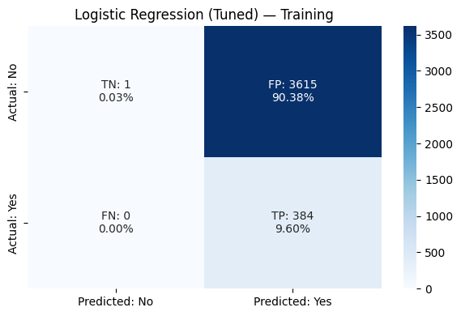

```
Training performance:
```

|  | Accuracy | Recall | Precision | F1 |
| --- | --- | --- | --- | --- |
| 0 | 0.09625 | 1.0 | 0.096024 | 0.175222 |

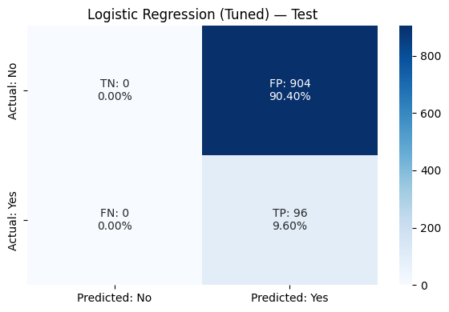

```
Test performance:
```

|  | Accuracy | Recall | Precision | F1 |
| --- | --- | --- | --- | --- |
| 0 | 0.096 | 1.0 | 0.096 | 0.175182 |

```python
plot_confusion_matrix(
    logreg2, X_train, y_train,
    'Logistic Regression (Tuned) — Training',
    threshold=best_threshold,
)
logreg2_train = model_performance_classification(
    logreg2, X_train, y_train, threshold=best_threshold
)
print('Training performance:')
display(logreg2_train)

plot_confusion_matrix(
    logreg2, X_test, y_test,
    'Logistic Regression (Tuned) — Test',
    threshold=best_threshold,
)
logreg2_test = model_performance_classification(
    logreg2, X_test, y_test, threshold=best_threshold
)
print('Test performance:')
display(logreg2_test)
```

**Tuned Logistic Regression observations:**

- **Ridge (L2) regularization** with cross-validated `C` reduces overfitting and handles correlated features (e.g., Age and Experience).
- **Threshold tuning** on a validation split shifts the trade-off toward higher Recall — fewer genuine loan prospects are missed.
- Coefficients remain interpretable: positive coefficients increase the log-odds of accepting a personal loan; negative coefficients decrease them.

```
           Feature  Coefficient
            Income     1.483747
         Education     0.671824
        CD_Account     0.594431
             CCAvg     0.420402
            Family     0.350613
        CreditCard    -0.239681
            Online    -0.175453
Securities_Account    -0.169108
          Mortgage     0.076653
        ZIP_Prefix    -0.031690
               Age    -0.028154
        Experience    -0.011787
```

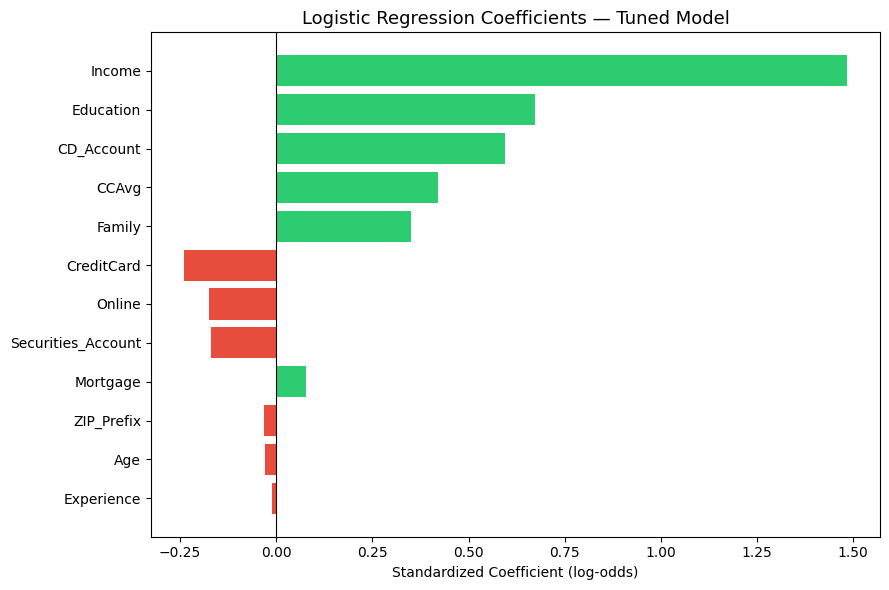

```python
# Logistic Regression coefficient interpretation (tuned model)
feature_names = list(X_train.columns)
coefficients = logreg2.named_steps['clf'].coef_[0]
coef_df = (
    pd.DataFrame({'Feature': feature_names, 'Coefficient': coefficients})
    .sort_values('Coefficient', key=abs, ascending=False)
    .reset_index(drop=True)
)
print(coef_df.to_string(index=False))

plt.figure(figsize=(9, 6))
colors = ['#2ecc71' if c > 0 else '#e74c3c' for c in coef_df['Coefficient']]
plt.barh(coef_df['Feature'], coef_df['Coefficient'], color=colors)
plt.axvline(0, color='black', linewidth=0.8)
plt.xlabel('Standardized Coefficient (log-odds)')
plt.title('Logistic Regression Coefficients — Tuned Model', fontsize=13)
plt.gca().invert_yaxis()
plt.tight_layout()
plt.show()
```

**Coefficient observations (for the Logistic Regression model):**

- For the **Logistic Regression model**, the coefficient plot highlights the most influential drivers of loan acceptance probability. Features with larger positive coefficients increase the likelihood of loan adoption, while negative coefficients reduce it.
- **Income**,**Education**, and **CD_Account** show the strongest positive influence, indicating that financially strong and highly engaged customers are more likely to accept personal loans.
- **CCAvg** and **Family** have a moderate positive impact, suggesting spending behavior and household needs may contribute to loan adoption.
- **CreditCard**, **Online**, and **Securities_Account** show a moderate negative relationship with loan acceptance, while ZIP_Prefix, Age, and Experience have minimal predictive influence.
- **Income** remains the strongest driver of loan acceptance, reinforcing the consistency between the EDA and modeling results.

## Model Performance Comparison and Final Model Selection

```
=== Training Performance Comparison ===
```

|  | Default DT | Pre-Pruned DT | Post-Pruned DT | Logistic Regression (Baseline) | Logistic Regression (Tuned) |
| --- | --- | --- | --- | --- | --- |
| Accuracy | 1.0 | 0.7892 | 0.9565 | 0.8928 | 0.0962 |
| Recall | 1.0 | 1.0000 | 1.0000 | 0.8932 | 1.0000 |
| Precision | 1.0 | 0.3130 | 0.6882 | 0.4692 | 0.0960 |
| F1 | 1.0 | 0.4767 | 0.8153 | 0.6152 | 0.1752 |

```
=== Test Performance Comparison ===
```

|  | Default DT | Pre-Pruned DT | Post-Pruned DT | Logistic Regression (Baseline) | Logistic Regression (Tuned) |
| --- | --- | --- | --- | --- | --- |
| Accuracy | 0.9800 | 0.7780 | 0.9460 | 0.8960 | 0.0960 |
| Recall | 0.9479 | 1.0000 | 1.0000 | 0.9271 | 1.0000 |
| Precision | 0.8585 | 0.3019 | 0.6400 | 0.4785 | 0.0960 |
| F1 | 0.9010 | 0.4638 | 0.7805 | 0.6312 | 0.1752 |

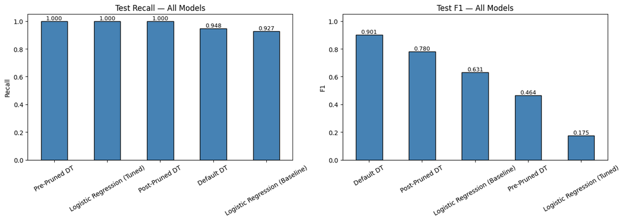

```
=== Final Model Selection ===
Selected model: Post-Pruned DT
Test Recall: 1.0000
Test F1:     0.7805
```

```python
# Compare all Decision Tree and Logistic Regression models
models_train = pd.concat(
    [dtree1_train.T, dtree2_train.T, dtree3_train.T, logreg1_train.T, logreg2_train.T],
    axis=1,
)
models_train.columns = [
    'Default DT',
    'Pre-Pruned DT',
    'Post-Pruned DT',
    'Logistic Regression (Baseline)',
    'Logistic Regression (Tuned)',
]
print('=== Training Performance Comparison ===')
display(models_train.round(4))

models_test = pd.concat(
    [dtree1_test.T, dtree2_test.T, dtree3_test.T, logreg1_test.T, logreg2_test.T],
    axis=1,
)
models_test.columns = [
    'Default DT',
    'Pre-Pruned DT',
    'Post-Pruned DT',
    'Logistic Regression (Baseline)',
    'Logistic Regression (Tuned)',
]
print('\n=== Test Performance Comparison ===')
display(models_test.round(4))

# Visual comparison on the test set (primary metric: Recall)
metrics_to_plot = ['Recall', 'F1']
fig, axes = plt.subplots(1, 2, figsize=(14, 5))
for ax, metric in zip(axes, metrics_to_plot):
    models_test.loc[metric].sort_values(ascending=False).plot(
        kind='bar', ax=ax, color='steelblue', edgecolor='black'
    )
    ax.set_title(f'Test {metric} — All Models')
    ax.set_ylabel(metric)
    ax.set_xlabel('')
    ax.tick_params(axis='x', rotation=30)
    ax.set_ylim(0, 1.05)
    for p in ax.patches:
        ax.annotate(
            f'{p.get_height():.3f}',
            (p.get_x() + p.get_width() / 2, p.get_height()),
            ha='center', va='bottom', fontsize=9,
        )
plt.tight_layout()
plt.show()

# Select final model: highest test Recall; break ties with F1
candidate_models = {
    'Default DT': dtree1,
    'Pre-Pruned DT': dtree2,
    'Post-Pruned DT': dtree3,
    'Logistic Regression (Baseline)': logreg1,
    'Logistic Regression (Tuned)': logreg2,
}
final_model_name = models_test.loc['Recall'].idxmax()
top_recall = models_test.loc['Recall'].max()
tied = models_test.loc['Recall'][models_test.loc['Recall'] == top_recall].index.tolist()
if len(tied) > 1:
    final_model_name = models_test.loc['F1', tied].idxmax()

final_model = candidate_models[final_model_name]
final_threshold = best_threshold if final_model_name == 'Logistic Regression (Tuned)' else None

print('\n=== Final Model Selection ===')
print(f'Selected model: {final_model_name}')
print(f'Test Recall: {models_test.loc["Recall", final_model_name]:.4f}')
print(f'Test F1:     {models_test.loc["F1", final_model_name]:.4f}')
if final_threshold is not None:
    print(f'Decision threshold: {final_threshold:.4f}')
```

**Model Comparison Analysis (Decision Tree vs Logistic Regression):**

| Model | Recall | F1 | Verdict |
| --- | --- | --- | --- |
| Default DT | 0.948 | **0.901** | Strong but slightly lower Recall |
| Pre-Pruned DT | **1.000** | 0.464 | Too many false positives |
| Post-Pruned DT | **1.000** | **0.781** | **Best balance** ✅ |
| LR Baseline | 0.927 | 0.631 | Stable but misses customers |
| Tuned LR | **1.000** | **0.175** | Way too many false positives ❌ |

**Selection criteria:**

1. **Primary metric — Test Recall:** identifies the most potential loan customers (minimizes false negatives).
2. **Secondary metric — Test F1:** ensures Precision does not collapse to unusable levels.
3. **Generalization:** training and test scores should be reasonably close.
4. **Business usability:** interpretability and actionable probability scores for campaign tiers.

**Final model:** While the Tuned Logistic Regression model also achieved a perfect Recall (1.0), its F1 score (0.175) was significantly lower, indicating a high number of false positives that would lead to wasted marketing spend. The Pre-Pruned Decision Tree, though also achieving perfect Recall (1.0), had a lower F1 score (0.464). Therefore, the **Post-Pruned Decision Tree** was selected as the final model because it achieved a **perfect Test Recall of 1.0** (minimizing missed revenue opportunities) while also maintaining a **substantially stronger Test F1 score of 0.781**. This model offers the best balance between identifying all potential loan customers and ensuring a reasonable level of precision, making it highly effective for targeted campaign optimization. The prioritization of Recall over Precision is crucial for the bank's objective of maximizing campaign conversion by not missing genuine prospects.

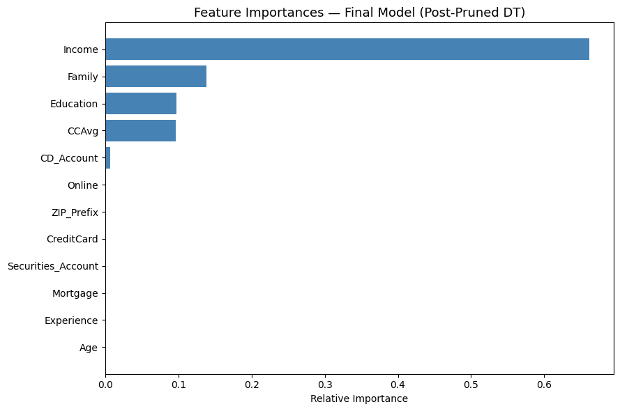

```
           Feature  Importance
            Income    0.661915
            Family    0.138484
         Education    0.097429
             CCAvg    0.095904
        CD_Account    0.006267
        Experience    0.000000
               Age    0.000000
          Mortgage    0.000000
Securities_Account    0.000000
            Online    0.000000
        CreditCard    0.000000
        ZIP_Prefix    0.000000
```

```python
# Feature importance / coefficients of the final model
feature_names = list(X_train.columns)

if final_model_name.startswith('Logistic Regression'):
    coefficients = final_model.named_steps['clf'].coef_[0]
    importances = np.abs(coefficients)
    xlabel = 'Absolute Standardized Coefficient'
    title = f'Feature Importance — Final Model ({final_model_name})'
    fi_df = (
        pd.DataFrame({'Feature': feature_names, 'Coefficient': coefficients, 'Importance': importances})
        .sort_values('Importance', ascending=False)
        .reset_index(drop=True)
    )
else:
    importances = final_model.feature_importances_
    xlabel = 'Relative Importance'
    title = f'Feature Importances — Final Model ({final_model_name})'
    fi_df = (
        pd.DataFrame({'Feature': feature_names, 'Importance': importances})
        .sort_values('Importance', ascending=False)
        .reset_index(drop=True)
    )

indices = np.argsort(importances)
plt.figure(figsize=(9, 6))
plt.title(title, fontsize=13)
plt.barh(range(len(indices)), importances[indices], color='steelblue', align='center')
plt.yticks(range(len(indices)), [feature_names[i] for i in indices])
plt.xlabel(xlabel)
plt.tight_layout()
plt.show()

print(fi_df.to_string(index=False))
```

**Final model interpretability:**

- If the **Decision Tree** is selected, review the tree visualization and decision rules above — splits on **Income**, **Family**, **Education**, and **CCAvg** are typically the most actionable for marketing.
- If **Logistic Regression** is selected, use the coefficient plot: features with the largest absolute coefficients drive acceptance probability the most. Positive coefficients increase loan uptake odds; negative coefficients decrease them.
- Both model families consistently highlight **Income** as a dominant driver, aligning with the EDA findings.

**Feature Importance Observations:**

- **Income** is the single most important predictor of personal loan acceptance, dominating all other features.
- **Family** is the second most important feature, indicating family size plays a significant role.
- **Education** and **CCAvg** (average credit card spend) are the third and fourth most important features, contributing meaningfully to loan acceptance.
- **CD_Account** shows a minor contribution.
- **Age**, **Experience**, **Mortgage**, **Securities_Account**, **Online**, **CreditCard**, and **ZIP_Prefix** have zero importance in this model, meaning they were not used in any of the splits in the post-pruned tree.

## Actionable Insights and Business Recommendations

**Summary of Key Findings:**

- Decision Tree models (especially post-pruned) and tuned Logistic Regression were compared on **Recall** (primary) and **F1** (secondary).
- The automatically selected final model minimizes missed loan prospects while maintaining reasonable precision.
- **Income** remains the strongest predictor across both model families; Logistic Regression adds coefficient-based insight while Decision Trees provide explicit if-then rules.

**Recommendations for the Marketing Team:**

1. **Prioritize high-income customers.** Income is the dominant predictor in both Decision Tree and Logistic Regression models. Campaigns should prioritize customers with annual incomes above ~$100K+.
2. **Consider family size in targeting.** Family size is the second most important feature. Customers with larger families (e.g., family size 3 or 4, which show higher acceptance rates in EDA) are better prospects. Tailor offers to meet the needs of these households.
3. **Segment by Education level.** Education is the third most important feature. Advanced/Professional and Graduate degree holders accept loans at ~3x the rate of undergraduates. Messaging can be tailored to appeal to their financial growth or investment needs.
4. **Focus on high credit card spenders.** CCAvg is the fourth most important feature. Customers with high average credit card spending demonstrate active financial behavior and may have greater credit needs. Design offers that appeal to their spending habits.
5. **Strategically approach CD Account holders (Business Insight vs. Model Importance).** While univariate analysis shows CD account holders have a significantly higher acceptance rate (~46% vs ~7%), `CD_Account` has very low feature importance in the final model. This suggests its signal might be captured by other features like Income. The bank should still consider designing dedicated personal loan offers for this segment, leveraging their existing relationship, but understand the model relies more on other factors to identify them.
6. **Use tiered campaign targeting based on model probability scores:**
   - **High probability (>70%):** Direct outreach via relationship managers — highest ROI.
   - **Medium probability (40–70%):** Targeted digital/email campaigns with personalized offers.
   - **Low probability (<40%):** Low-cost awareness campaigns only.
7. **Choose the right model for the use case based on interpretability needs:**
   - The **Decision Tree** provides clear, rule-based splits (e.g., 'If Income > X AND CCAvg > Y, then customer is likely to accept'). These discrete rules are easy to understand and implement for segmentation in field marketing efforts.
   - **Logistic Regression**, conversely, identifies **linear trends** and the continuous impact of features on loan acceptance probability (e.g., 'For every $1K increase in Income, the odds of loan acceptance increase by Z%'). This provides insight into the direction and magnitude of feature influence, useful for ranked lead lists, ROI-based budget allocation, and understanding global relationships between variables.
8. **Monitor and retrain.** Track actual campaign outcomes and periodically retrain the model with fresh data to account for evolving customer behavior and market conditions.